# CPS Data Generation Report

Overview of Derived Datasets for PhD Unemployment Analysis

Author

PhD Unemployment Model Project

Published

May 25, 2026

## Overview

This report documents the three core datasets generated from raw IPUMS CPS microdata for PhD unemployment analysis. These datasets support different modeling approaches:

1. **Education Spectrum Counts**: Unweighted person counts for binomial/quasi-binomial GAMs
2. **PhD Monthly Unemployment**: PhD-specific time series for seasonal analysis
3. **Multi-Education Unemployment**: Weighted data for cross-education comparisons

All datasets are generated by the reproducible pipeline in `data-raw/generate-derived-data.R`.

```r
library(ggplot2)
library(here)

# Load the three core datasets
edu_counts <- readRDS(here("data", "education-spectrum-counts.rds"))
phd_monthly <- readRDS(here("data", "phd-monthly-unemployment.rds"))
multi_edu <- readRDS(here("data", "multi-education-unemployment.rds"))

# Add date columns where missing
# Use unclass() to strip haven_labelled attributes
if (!"date" %in% names(edu_counts)) {
  edu_counts$date <- as.Date(paste(edu_counts$year, unclass(edu_counts$month), "01", sep = "-"))
}
if (!"date" %in% names(multi_edu)) {
  multi_edu$date <- as.Date(paste(multi_edu$year, unclass(multi_edu$month), "01", sep = "-"))
}

# Set ggplot theme
theme_set(theme_minimal(base_size = 12))
```

## Dataset 1: Education Spectrum Counts

**Purpose**: Unweighted person counts for binomial/quasi-binomial GAM modeling

**File**: `data/education-spectrum-counts.rds`

### Structure

```r
# Dimensions
cat("Dimensions:", nrow(edu_counts), "rows ×", ncol(edu_counts), "columns\n\n")
```

```
Dimensions: 2205 rows × 9 columns
```

```r
# Column names and types
cat("Columns:\n")
```

```
Columns:
```

```r
str(edu_counts)
```

```
'data.frame':   2205 obs. of  9 variables:
 $ year             : num  2000 2000 2000 2000 2000 2000 2000 2000 2000 2000 ...
  ..- attr(*, "label")= chr "Survey year"
  ..- attr(*, "var_desc")= chr "YEAR reports the year in which the survey was conducted.  YEARP is repeated on person records."
 $ month            : int  1 1 1 1 1 1 1 2 2 2 ...
 $ education        : chr  "bachelors" "high_school" "less_than_hs" "masters" ...
 $ n_employed       : int  11369 19053 7310 3824 775 963 17163 11291 18594 7188 ...
 $ n_unemployed     : int  253 990 910 63 11 9 618 217 959 873 ...
 $ n_total          : int  11622 20043 8220 3887 786 972 17781 11508 19553 8061 ...
 $ unemployment_rate: num  0.0218 0.0494 0.1107 0.0162 0.014 ...
 $ time_index       : int  1 1 1 1 1 1 1 2 2 2 ...
 $ date             : Date, format: "2000-01-01" "2000-01-01" ...
```

```r
# Time range
cat("\nTime range:", min(edu_counts$year), "-", max(edu_counts$year), "\n")
```

```
Time range: 2000 - 2026
```

```r
# Education levels
cat("Education levels:", length(unique(edu_counts$education)), "\n")
```

```
Education levels: 7
```

```r
cat("  ", paste(sort(unique(edu_counts$education)), collapse = ", "), "\n")
```

```
   bachelors, high_school, less_than_hs, masters, phd, professional, some_college
```

### Sample Data

```r
head(edu_counts, 10)
```

```
   year month    education n_employed n_unemployed n_total unemployment_rate
1  2000     1    bachelors      11369          253   11622       0.021769059
2  2000     1  high_school      19053          990   20043       0.049393803
3  2000     1 less_than_hs       7310          910    8220       0.110705596
4  2000     1      masters       3824           63    3887       0.016207872
5  2000     1          phd        775           11     786       0.013994911
6  2000     1 professional        963            9     972       0.009259259
7  2000     1 some_college      17163          618   17781       0.034756200
8  2000     2    bachelors      11291          217   11508       0.018856448
9  2000     2  high_school      18594          959   19553       0.049046182
10 2000     2 less_than_hs       7188          873    8061       0.108299218
   time_index       date
1           1 2000-01-01
2           1 2000-01-01
3           1 2000-01-01
4           1 2000-01-01
5           1 2000-01-01
6           1 2000-01-01
7           1 2000-01-01
8           2 2000-02-01
9           2 2000-02-01
10          2 2000-02-01
```

### Summary Statistics

```r
cat("Total unemployed persons:", format(sum(edu_counts$n_unemployed), big.mark = ","), "\n")
```

```
Total unemployed persons: 1,123,800
```

```r
cat("Total labor force:", format(sum(edu_counts$n_total), big.mark = ","), "\n")
```

```
Total labor force: 20,673,076
```

```r
cat("Overall unemployment rate:", sprintf("%.2f%%", 100 * mean(edu_counts$unemployment_rate)), "\n")
```

```
Overall unemployment rate: 4.57%
```

### Visualization: Unemployment Rates by Education Over Time

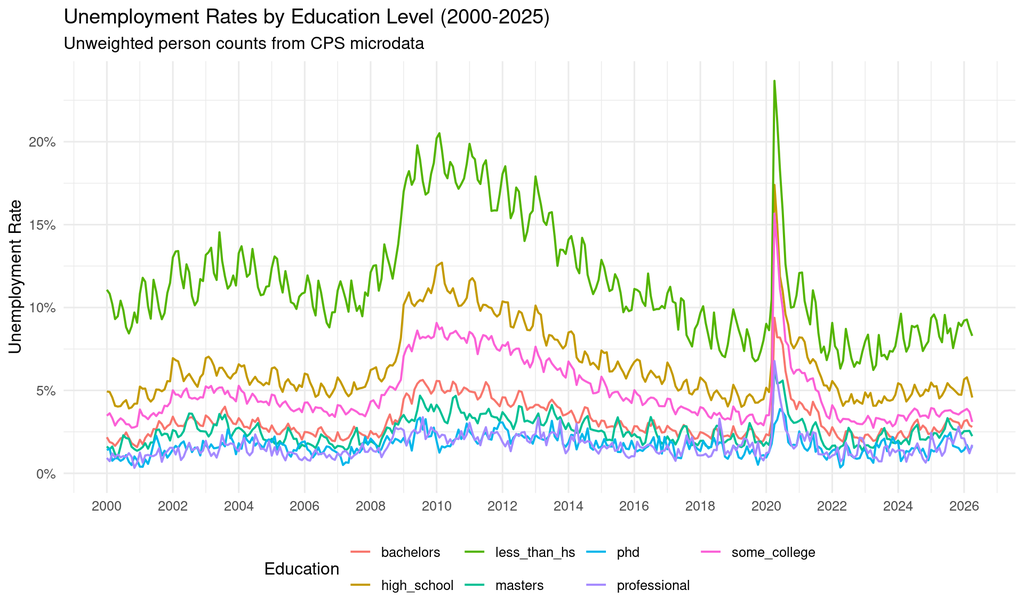

```r
ggplot(edu_counts, aes(x = date, y = unemployment_rate, color = education)) +
  geom_line(linewidth = 0.7) +
  scale_y_continuous(labels = scales::percent_format(), limits = c(0, NA)) +
  scale_x_date(date_breaks = "2 years", date_labels = "%Y") +
  labs(
    title = "Unemployment Rates by Education Level (2000-2025)",
    subtitle = "Unweighted person counts from CPS microdata",
    x = NULL,
    y = "Unemployment Rate",
    color = "Education"
  ) +
  theme(legend.position = "bottom") +
  guides(color = guide_legend(nrow = 2))
```

### Visualization: Average Unemployment by Education

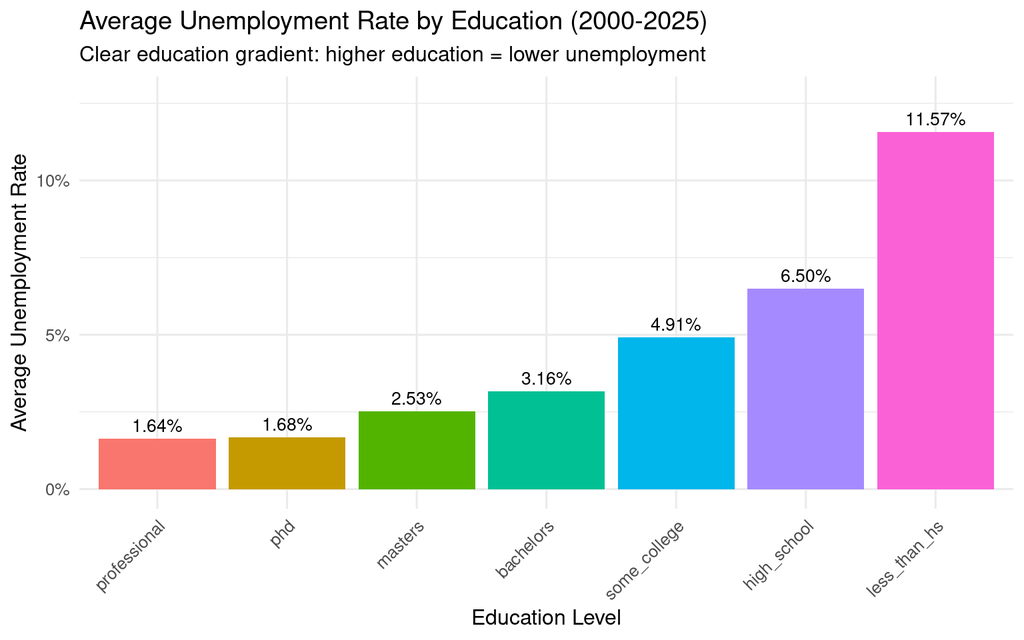

```r
# Calculate average by education
edu_avg <- aggregate(unemployment_rate ~ education, data = edu_counts, FUN = mean)
edu_avg <- edu_avg[order(edu_avg$unemployment_rate), ]
edu_avg$education <- factor(edu_avg$education, levels = edu_avg$education)

ggplot(edu_avg, aes(x = education, y = unemployment_rate, fill = education)) +
  geom_col(show.legend = FALSE) +
  geom_text(aes(label = sprintf("%.2f%%", 100 * unemployment_rate)),
            vjust = -0.5, size = 3.5) +
  scale_y_continuous(labels = scales::percent_format(),
                     limits = c(0, max(edu_avg$unemployment_rate) * 1.1)) +
  labs(
    title = "Average Unemployment Rate by Education (2000-2025)",
    subtitle = "Clear education gradient: higher education = lower unemployment",
    x = "Education Level",
    y = "Average Unemployment Rate"
  ) +
  theme(axis.text.x = element_text(angle = 45, hjust = 1))
```

### Visualization: Counts vs Rates

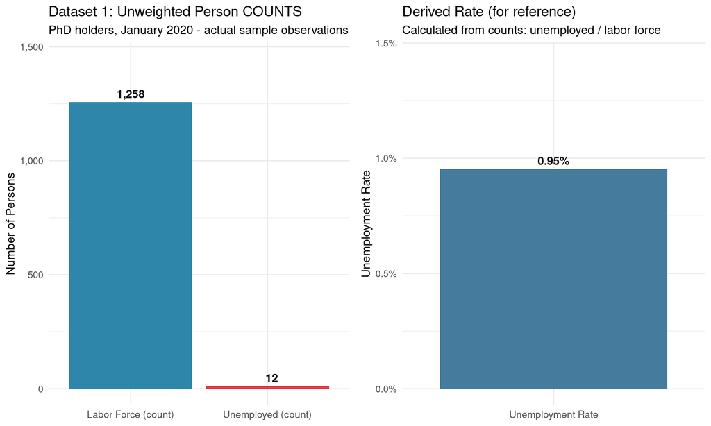

```r
# Show that this dataset contains COUNTS not RATES
# Pick PhD data for Jan 2020 as example
phd_jan_2020 <- edu_counts[edu_counts$education == "phd" &
                            edu_counts$year == 2020 &
                            unclass(edu_counts$month) == 1, ]

# Create example data frame
count_example <- data.frame(
  Measure = c("Unemployed (count)", "Labor Force (count)", "Unemployment Rate"),
  Value = c(phd_jan_2020$n_unemployed,
            phd_jan_2020$n_total,
            phd_jan_2020$unemployment_rate),
  Type = c("Count", "Count", "Rate")
)

# Create two separate plots
library(gridExtra)

# Plot 1: Counts (absolute numbers)
p1 <- ggplot(count_example[count_example$Type == "Count", ],
             aes(x = Measure, y = Value, fill = Measure)) +
  geom_col(show.legend = FALSE) +
  geom_text(aes(label = format(round(Value), big.mark = ",")),
            vjust = -0.5, size = 4, fontface = "bold") +
  scale_y_continuous(labels = scales::comma, limits = c(0, max(count_example$Value[1:2]) * 1.15)) +
  scale_fill_manual(values = c("Unemployed (count)" = "#E63946",
                                "Labor Force (count)" = "#2E86AB")) +
  labs(
    title = "Dataset 1: Unweighted Person COUNTS",
    subtitle = "PhD holders, January 2020 - actual sample observations",
    x = NULL,
    y = "Number of Persons"
  ) +
  theme(axis.text.x = element_text(size = 10))

# Plot 2: Rate (proportion)
p2 <- ggplot(count_example[count_example$Type == "Rate", ],
             aes(x = Measure, y = Value, fill = Measure)) +
  geom_col(show.legend = FALSE, fill = "#457B9D") +
  geom_text(aes(label = sprintf("%.2f%%", 100 * Value)),
            vjust = -0.5, size = 4, fontface = "bold") +
  scale_y_continuous(labels = scales::percent, limits = c(0, max(count_example$Value[3]) * 1.5)) +
  labs(
    title = "Derived Rate (for reference)",
    subtitle = "Calculated from counts: unemployed / labor force",
    x = NULL,
    y = "Unemployment Rate"
  ) +
  theme(axis.text.x = element_text(size = 10))

# Combine plots
gridExtra::grid.arrange(p1, p2, ncol = 2)
```

**Key Difference**: Dataset 1 stores **integer counts** (n_unemployed = 12, n_total = 1258) suitable for binomial models, while the rate (0.95%) is derived from these counts.

## Dataset 2: PhD Monthly Unemployment

**Purpose**: PhD-specific time series for seasonal GAM modeling

**File**: `data/phd-monthly-unemployment.rds`

### Structure

```r
# Dimensions
cat("Dimensions:", nrow(phd_monthly), "rows ×", ncol(phd_monthly), "columns\n\n")
```

```
Dimensions: 315 rows × 11 columns
```

```r
# Column names and types
cat("Columns:\n")
```

```
Columns:
```

```r
str(phd_monthly)
```

```
'data.frame':   315 obs. of  11 variables:
 $ year             : num  2000 2000 2000 2000 2000 2000 2000 2000 2000 2000 ...
  ..- attr(*, "label")= chr "Survey year"
  ..- attr(*, "var_desc")= chr "YEAR reports the year in which the survey was conducted.  YEARP is repeated on person records."
 $ month            : int  1 2 3 4 5 6 7 8 9 10 ...
 $ n_employed       : num  1711649 1752536 1663036 1667058 1700248 ...
 $ n_unemployed     : num  23770 24786 14560 13464 13743 ...
 $ n_total          : num  1735419 1777322 1677596 1680522 1713991 ...
 $ unemployment_rate: num  0.0137 0.01395 0.00868 0.00801 0.00802 ...
 $ time_index       : int  1 2 3 4 5 6 7 8 9 10 ...
 $ date             : Date, format: "2000-01-01" "2000-02-01" ...
 $ YEAR             : num  2000 2000 2000 2000 2000 2000 2000 2000 2000 2000 ...
  ..- attr(*, "label")= chr "Survey year"
  ..- attr(*, "var_desc")= chr "YEAR reports the year in which the survey was conducted.  YEARP is repeated on person records."
 $ MONTH            : int  1 2 3 4 5 6 7 8 9 10 ...
 $ n_obs            : num  1735419 1777322 1677596 1680522 1713991 ...
```

```r
# Time range
cat("\nTime range:", format(min(phd_monthly$date), "%Y-%m"), "to",
    format(max(phd_monthly$date), "%Y-%m"), "\n")
```

```
Time range: 2000-01 to 2026-04
```

```r
cat("Total months:", nrow(phd_monthly), "\n")
```

```
Total months: 315
```

### Sample Data

```r
head(phd_monthly, 10)
```

```
   year month n_employed n_unemployed n_total unemployment_rate time_index
1  2000     1    1711649    23769.518 1735419       0.013696703          1
2  2000     2    1752536    24786.415 1777322       0.013945932          2
3  2000     3    1663036    14560.410 1677596       0.008679330          3
4  2000     4    1667058    13463.986 1680522       0.008011787          4
5  2000     5    1700248    13743.126 1713991       0.008018203          5
6  2000     6    1743729    11514.323 1755243       0.006559959          6
7  2000     7    1767384    13032.529 1780417       0.007319932          7
8  2000     8    1790698    23254.268 1813952       0.012819668          8
9  2000     9    1953738    14481.523 1968219       0.007357678          9
10 2000    10    1834338     9525.073 1843863       0.005165825         10
         date YEAR MONTH   n_obs
1  2000-01-01 2000     1 1735419
2  2000-02-01 2000     2 1777322
3  2000-03-01 2000     3 1677596
4  2000-04-01 2000     4 1680522
5  2000-05-01 2000     5 1713991
6  2000-06-01 2000     6 1755243
7  2000-07-01 2000     7 1780417
8  2000-08-01 2000     8 1813952
9  2000-09-01 2000     9 1968219
10 2000-10-01 2000    10 1843863
```

### Summary Statistics

```r
cat("Mean unemployment rate:", sprintf("%.2f%%", 100 * mean(phd_monthly$unemployment_rate)), "\n")
```

```
Mean unemployment rate: 1.73%
```

```r
cat("Min unemployment rate:", sprintf("%.2f%%", 100 * min(phd_monthly$unemployment_rate)), "\n")
```

```
Min unemployment rate: 0.29%
```

```r
cat("Max unemployment rate:", sprintf("%.2f%%", 100 * max(phd_monthly$unemployment_rate)), "\n")
```

```
Max unemployment rate: 4.40%
```

```r
cat("SD unemployment rate:", sprintf("%.2f%%", 100 * sd(phd_monthly$unemployment_rate)), "\n")
```

```
SD unemployment rate: 0.67%
```

```r
cat("\nMean sample size (weighted):", format(round(mean(phd_monthly$n_total)), big.mark = ","), "\n")
```

```
Mean sample size (weighted): 2,757,678
```

### Visualization: PhD Unemployment Time Series

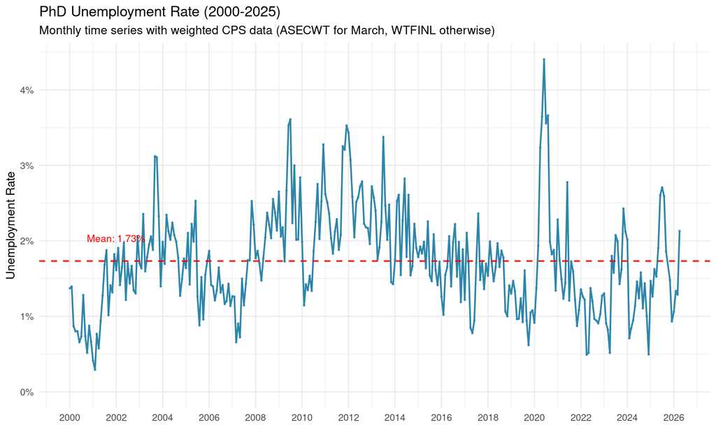

```r
ggplot(phd_monthly, aes(x = date, y = unemployment_rate)) +
  geom_line(color = "#2E86AB", linewidth = 0.8) +
  geom_point(color = "#2E86AB", size = 0.5, alpha = 0.6) +
  geom_hline(yintercept = mean(phd_monthly$unemployment_rate),
             linetype = "dashed", color = "red", linewidth = 0.7) +
  annotate("text", x = as.Date("2002-01-01"),
           y = mean(phd_monthly$unemployment_rate) + 0.003,
           label = sprintf("Mean: %.2f%%", 100 * mean(phd_monthly$unemployment_rate)),
           color = "red", size = 3.5) +
  scale_y_continuous(labels = scales::percent_format(), limits = c(0, NA)) +
  scale_x_date(date_breaks = "2 years", date_labels = "%Y") +
  labs(
    title = "PhD Unemployment Rate (2000-2025)",
    subtitle = "Monthly time series with weighted CPS data (ASECWT for March, WTFINL otherwise)",
    x = NULL,
    y = "Unemployment Rate"
  )
```

### Visualization: PhD Unemployment by Month (Seasonal Pattern)

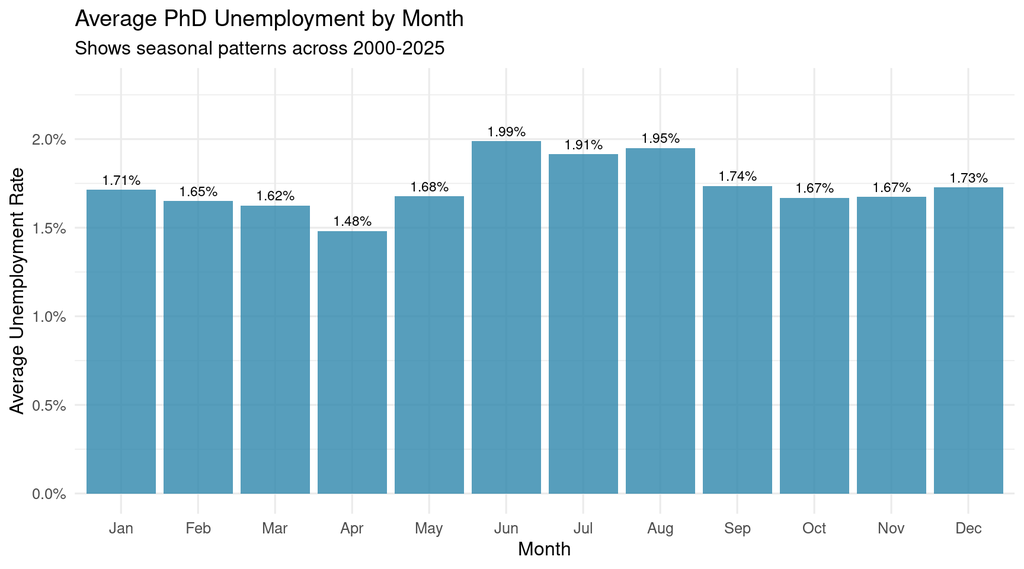

```r
# Calculate average by month
monthly_avg <- aggregate(unemployment_rate ~ month, data = phd_monthly, FUN = mean)
monthly_avg$month_name <- month.abb[monthly_avg$month]
monthly_avg$month_name <- factor(monthly_avg$month_name, levels = month.abb)

ggplot(monthly_avg, aes(x = month_name, y = unemployment_rate)) +
  geom_col(fill = "#2E86AB", alpha = 0.8) +
  geom_text(aes(label = sprintf("%.2f%%", 100 * unemployment_rate)),
            vjust = -0.5, size = 3) +
  scale_y_continuous(labels = scales::percent_format(),
                     limits = c(0, max(monthly_avg$unemployment_rate) * 1.15)) +
  labs(
    title = "Average PhD Unemployment by Month",
    subtitle = "Shows seasonal patterns across 2000-2025",
    x = "Month",
    y = "Average Unemployment Rate"
  )
```

### Visualization: Recent Trends (2020-2025)

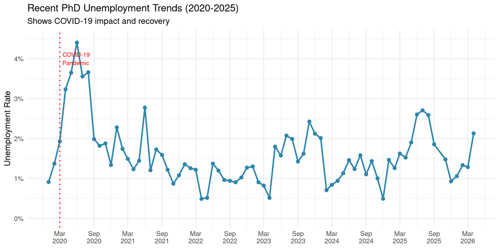

```r
# Filter to recent years
phd_recent <- phd_monthly[phd_monthly$year >= 2020, ]

ggplot(phd_recent, aes(x = date, y = unemployment_rate)) +
  geom_line(color = "#2E86AB", linewidth = 1) +
  geom_point(color = "#2E86AB", size = 2) +
  geom_vline(xintercept = as.Date("2020-03-01"),
             linetype = "dotted", color = "red", linewidth = 0.8) +
  annotate("text", x = as.Date("2020-03-01"), y = 0.04,
           label = "COVID-19\nPandemic", color = "red", size = 3, hjust = -0.1) +
  scale_y_continuous(labels = scales::percent_format(), limits = c(0, 0.045)) +
  scale_x_date(date_breaks = "6 months", date_labels = "%b\n%Y") +
  labs(
    title = "Recent PhD Unemployment Trends (2020-2025)",
    subtitle = "Shows COVID-19 impact and recovery",
    x = NULL,
    y = "Unemployment Rate"
  )
```

## Dataset 3: Multi-Education Unemployment

**Purpose**: Weighted data for cross-education comparisons

**File**: `data/multi-education-unemployment.rds`

### Structure

```r
# Dimensions
cat("Dimensions:", nrow(multi_edu), "rows ×", ncol(multi_edu), "columns\n\n")
```

```
Dimensions: 2205 rows × 9 columns
```

```r
# Column names and types
cat("Columns:\n")
```

```
Columns:
```

```r
str(multi_edu)
```

```
'data.frame':   2205 obs. of  9 variables:
 $ year             : num  2000 2000 2000 2000 2000 2000 2000 2000 2000 2000 ...
  ..- attr(*, "label")= chr "Survey year"
  ..- attr(*, "var_desc")= chr "YEAR reports the year in which the survey was conducted.  YEARP is repeated on person records."
 $ month            : int  1 1 1 1 1 1 1 2 2 2 ...
 $ education        : chr  "bachelors" "high_school" "less_than_hs" "masters" ...
 $ n_employed       : num  25215401 42515324 17292601 8433520 1711649 ...
 $ n_unemployed     : num  570959 2201073 2132386 143071 23770 ...
 $ n_total          : num  25786360 44716397 19424987 8576591 1735419 ...
 $ unemployment_rate: num  0.0221 0.0492 0.1098 0.0167 0.0137 ...
 $ time_index       : int  1 1 1 1 1 1 1 2 2 2 ...
 $ date             : Date, format: "2000-01-01" "2000-01-01" ...
```

```r
# Time range
cat("\nTime range:", min(multi_edu$year), "-", max(multi_edu$year), "\n")
```

```
Time range: 2000 - 2026
```

```r
# Education levels
cat("Education levels:", length(unique(multi_edu$education)), "\n")
```

```
Education levels: 7
```

```r
cat("  ", paste(sort(unique(multi_edu$education)), collapse = ", "), "\n")
```

```
   bachelors, high_school, less_than_hs, masters, phd, professional, some_college
```

### Sample Data

```r
head(multi_edu, 10)
```

```
   year month    education n_employed n_unemployed  n_total unemployment_rate
1  2000     1    bachelors   25215401    570958.97 25786360       0.022141899
2  2000     1  high_school   42515324   2201072.66 44716397       0.049222943
3  2000     1 less_than_hs   17292601   2132385.90 19424987       0.109775412
4  2000     1      masters    8433520    143071.00  8576591       0.016681569
5  2000     1          phd    1711649     23769.52  1735419       0.013696703
6  2000     1 professional    2114197     20295.59  2134493       0.009508391
7  2000     1 some_college   38105923   1354204.40 39460127       0.034318298
8  2000     2    bachelors   25398635    515707.28 25914343       0.019900458
9  2000     2  high_school   42055001   2155301.79 44210303       0.048751120
10 2000     2 less_than_hs   17176463   2062482.39 19238945       0.107203506
   time_index       date
1           1 2000-01-01
2           1 2000-01-01
3           1 2000-01-01
4           1 2000-01-01
5           1 2000-01-01
6           1 2000-01-01
7           1 2000-01-01
8           2 2000-02-01
9           2 2000-02-01
10          2 2000-02-01
```

### Summary by Education

```r
# Calculate summary statistics by education
edu_summary <- aggregate(
  cbind(unemployment_rate, n_total) ~ education,
  data = multi_edu,
  FUN = mean
)

# Format nicely
edu_summary_df <- data.frame(
  Education = edu_summary$education,
  Avg_Unemployment = sprintf("%.2f%%", 100 * edu_summary$unemployment_rate),
  Avg_Sample_Size = format(round(edu_summary$n_total), big.mark = ",")
)

print(edu_summary_df)
```

```
     Education Avg_Unemployment Avg_Sample_Size
1    bachelors            3.44%      34,537,592
2  high_school            6.97%      43,937,103
3 less_than_hs           11.79%      16,143,120
4      masters            2.68%      13,633,212
5          phd            1.73%       2,757,678
6 professional            1.74%       2,484,989
7 some_college            5.31%      43,909,791
```

### Visualization: Weighted vs Unweighted Comparison

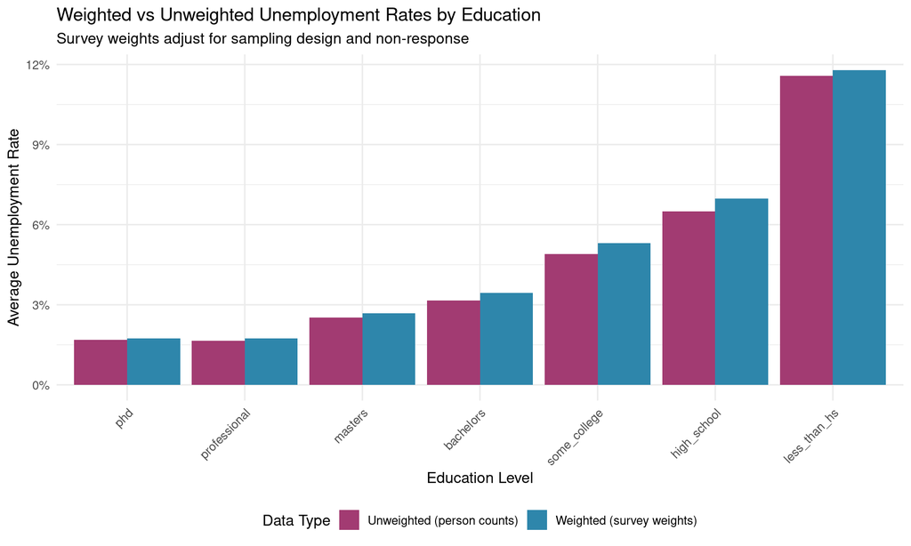

```r
# Calculate averages for both datasets
weighted_avg <- aggregate(unemployment_rate ~ education, data = multi_edu, FUN = mean)
weighted_avg$type <- "Weighted (survey weights)"

unweighted_avg <- aggregate(unemployment_rate ~ education, data = edu_counts, FUN = mean)
unweighted_avg$type <- "Unweighted (person counts)"

# Combine
comparison <- rbind(weighted_avg, unweighted_avg)

# Order by weighted average
edu_order <- weighted_avg$education[order(weighted_avg$unemployment_rate)]
comparison$education <- factor(comparison$education, levels = edu_order)

ggplot(comparison, aes(x = education, y = unemployment_rate, fill = type)) +
  geom_col(position = "dodge") +
  scale_y_continuous(labels = scales::percent_format()) +
  scale_fill_manual(values = c("Weighted (survey weights)" = "#2E86AB",
                                "Unweighted (person counts)" = "#A23B72")) +
  labs(
    title = "Weighted vs Unweighted Unemployment Rates by Education",
    subtitle = "Survey weights adjust for sampling design and non-response",
    x = "Education Level",
    y = "Average Unemployment Rate",
    fill = "Data Type"
  ) +
  theme(axis.text.x = element_text(angle = 45, hjust = 1),
        legend.position = "bottom")
```

### Visualization: Education Comparison Over Time

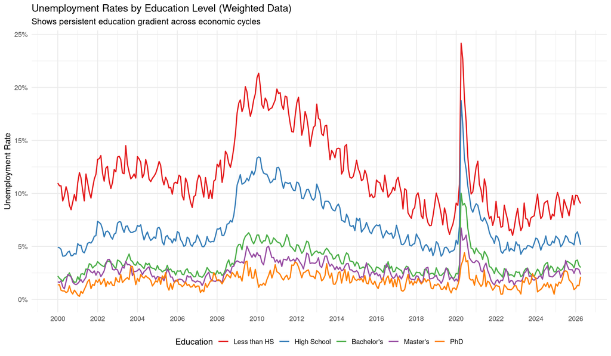

```r
# Filter to a few key education levels for clarity
key_education <- c("less_than_hs", "high_school", "bachelors", "masters", "phd")
multi_subset <- multi_edu[multi_edu$education %in% key_education, ]

# Create readable labels
label_map <- c(
  less_than_hs = "Less than HS",
  high_school = "High School",
  bachelors = "Bachelor's",
  masters = "Master's",
  phd = "PhD"
)
multi_subset$edu_label <- factor(
  label_map[multi_subset$education],
  levels = label_map
)

ggplot(multi_subset, aes(x = date, y = unemployment_rate, color = edu_label)) +
  geom_line(linewidth = 0.8) +
  scale_y_continuous(labels = scales::percent_format(), limits = c(0, NA)) +
  scale_x_date(date_breaks = "2 years", date_labels = "%Y") +
  scale_color_brewer(palette = "Set1") +
  labs(
    title = "Unemployment Rates by Education Level (Weighted Data)",
    subtitle = "Shows persistent education gradient across economic cycles",
    x = NULL,
    y = "Unemployment Rate",
    color = "Education"
  ) +
  theme(legend.position = "bottom")
```

## Data Quality Checks

### Completeness

```r
# Check for missing values
cat("Missing unemployment rates:\n")
```

```
Missing unemployment rates:
```

```r
cat("  Education Spectrum Counts:", sum(is.na(edu_counts$unemployment_rate)), "\n")
```

```
  Education Spectrum Counts: 0
```

```r
cat("  PhD Monthly:", sum(is.na(phd_monthly$unemployment_rate)), "\n")
```

```
  PhD Monthly: 0
```

```r
cat("  Multi-Education:", sum(is.na(multi_edu$unemployment_rate)), "\n\n")
```

```
  Multi-Education: 0
```

```r
# Check time coverage
cat("Time coverage (months):\n")
```

```
Time coverage (months):
```

```r
cat("  Education Spectrum Counts:", nrow(edu_counts) / length(unique(edu_counts$education)), "\n")
```

```
  Education Spectrum Counts: 315
```

```r
cat("  PhD Monthly:", nrow(phd_monthly), "\n")
```

```
  PhD Monthly: 315
```

```r
cat("  Multi-Education:", nrow(multi_edu) / length(unique(multi_edu$education)), "\n\n")
```

```
  Multi-Education: 315
```

```r
# Check sample sizes
cat("Mean sample sizes:\n")
```

```
Mean sample sizes:
```

```r
cat("  PhD Monthly (weighted):", format(round(mean(phd_monthly$n_total)), big.mark = ","), "\n")
```

```
  PhD Monthly (weighted): 2,757,678
```

```r
cat("  Education Spectrum (unweighted):", format(round(mean(edu_counts$n_total)), big.mark = ","), "\n")
```

```
  Education Spectrum (unweighted): 9,376
```

```r
cat("  Multi-Education (weighted):", format(round(mean(multi_edu$n_total)), big.mark = ","), "\n")
```

```
  Multi-Education (weighted): 22,486,212
```